# NYPD_Assignment

JAG

2026-09-21

## Introduction

The goal of this project is to analysis the seasonal victim counts throughout the 5 Boroughs of New York City. The 3 main questions I wish to analysis are as follows. 1. Do victim counts vary by by season throughout the Boroughs? 2. If they do, is it a consistent trend in all the Boroughs? And all Years? 3. Could we potentially use the data to predict the Victim count through the years?

```r
#import the shooting data
shooting.data = read.csv( "https://data.cityofnewyork.us/api/views/833y-fsy8/rows.csv?accessType=DOWNLOAD")

#view the data
glimpse(shooting.data)
```

```
## Rows: 29,744
## Columns: 21
## $ INCIDENT_KEY            <int> 231974218, 177934247, 255028563, 25384540, 726…
## $ OCCUR_DATE              <chr> "08/09/2021", "04/07/2018", "12/02/2022", "11/…
## $ OCCUR_TIME              <chr> "01:06:00", "19:48:00", "22:57:00", "01:50:00"…
## $ BORO                    <chr> "BRONX", "BROOKLYN", "BRONX", "BROOKLYN", "BRO…
## $ LOC_OF_OCCUR_DESC       <chr> "", "", "OUTSIDE", "", "", "", "", "", "", "",…
## $ PRECINCT                <int> 40, 79, 47, 66, 46, 42, 71, 69, 75, 69, 40, 42…
## $ JURISDICTION_CODE       <int> 0, 0, 0, 0, 0, 2, 0, 2, 0, 0, 0, 2, 0, 0, 2, 0…
## $ LOC_CLASSFCTN_DESC      <chr> "", "", "STREET", "", "", "", "", "", "", "", …
## $ LOCATION_DESC           <chr> "", "", "GROCERY/BODEGA", "PVT HOUSE", "MULTI …
## $ STATISTICAL_MURDER_FLAG <chr> "false", "true", "false", "true", "true", "fal…
## $ PERP_AGE_GROUP          <chr> "", "25-44", "(null)", "UNKNOWN", "25-44", "18…
## $ PERP_SEX                <chr> "", "M", "(null)", "U", "M", "M", "", "", "M",…
## $ PERP_RACE               <chr> "", "WHITE HISPANIC", "(null)", "UNKNOWN", "BL…
## $ VIC_AGE_GROUP           <chr> "18-24", "25-44", "25-44", "18-24", "<18", "18…
## $ VIC_SEX                 <chr> "M", "M", "M", "M", "F", "M", "M", "M", "M", "…
## $ VIC_RACE                <chr> "BLACK", "BLACK", "BLACK", "BLACK", "BLACK", "…
## $ X_COORD_CD              <chr> "1006343", "1000082.937500000000000", "1020691…
## $ Y_COORD_CD              <chr> "234270", "189064.671875000000000", "257125", …
## $ Latitude                <dbl> 40.80967, 40.68561, 40.87235, 40.64249, 40.845…
## $ Longitude               <dbl> -73.92019, -73.94291, -73.86823, -73.99691, -7…
## $ Lon_Lat                 <chr> "POINT (-73.92019278899994 40.80967347200004)"…
```

```r
head(shooting.data)
```

|  | INCIDENT_KEY | OCCUR_DATE | OCCUR_TIME | BORO | LOC_OF_OCCUR_DESC | PRECINCT | JURISDICTION_CODE | LOC_CLASSFCTN_DESC | LOCATION_DESC | STATISTICAL_MURDER_FLAG | PERP_AGE_GROUP | PERP_SEX | PERP_RACE | VIC_AGE_GROUP | VIC_SEX | VIC_RACE | X_COORD_CD | Y_COORD_CD | Latitude | Longitude | Lon_Lat |
| --- | --- | --- | --- | --- | --- | --- | --- | --- | --- | --- | --- | --- | --- | --- | --- | --- | --- | --- | --- | --- | --- |
| 1 | 231974218 | 08/09/2021 | 01:06:00 | BRONX |  | 40 | 0 |  |  | false |  |  |  | 18-24 | M | BLACK | 1006343 | 234270 | 40.80967 | -73.92019 | POINT (-73.92019278899994 40.80967347200004) |
| 2 | 177934247 | 04/07/2018 | 19:48:00 | BROOKLYN |  | 79 | 0 |  |  | true | 25-44 | M | WHITE HISPANIC | 25-44 | M | BLACK | 1000082.937500000000000 | 189064.671875000000000 | 40.68561 | -73.94291 | POINT (-73.94291302299996 40.685609672000055) |
| 3 | 255028563 | 12/02/2022 | 22:57:00 | BRONX | OUTSIDE | 47 | 0 | STREET | GROCERY/BODEGA | false | (null) | (null) | (null) | 25-44 | M | BLACK | 1020691 | 257125 | 40.87235 | -73.86823 | POINT (-73.868233 40.872349) |
| 4 | 25384540 | 11/19/2006 | 01:50:00 | BROOKLYN |  | 66 | 0 |  | PVT HOUSE | true | UNKNOWN | U | UNKNOWN | 18-24 | M | BLACK | 985107.312500000000000 | 173349.796875000000000 | 40.64249 | -73.99691 | POINT (-73.99691224999998 40.642489932000046) |
| 5 | 72616285 | 05/09/2010 | 01:58:00 | BRONX |  | 46 | 0 |  | MULTI DWELL - APT BUILD | true | 25-44 | M | BLACK | <18 | F | BLACK | 1009853.500000000000000 | 247502.562500000000000 | 40.84598 | -73.90746 | POINT (-73.90746098599993 40.84598358900007) |
| 6 | 85875439 | 07/22/2012 | 21:35:00 | BRONX |  | 42 | 2 |  | MULTI DWELL - PUBLIC HOUS | false | 18-24 | M | BLACK | 18-24 | M | BLACK | 1011046.687500000000000 | 239814.234375000000000 | 40.82488 | -73.90318 | POINT (-73.90317908399999 40.82487781900005) |

```r
#check if there are any missing values
shooting.data %>%
  summarise(across(everything(), ~ sum(is.na(.))))
```

| INCIDENT_KEY | OCCUR_DATE | OCCUR_TIME | BORO | LOC_OF_OCCUR_DESC | PRECINCT | JURISDICTION_CODE | LOC_CLASSFCTN_DESC | LOCATION_DESC | STATISTICAL_MURDER_FLAG | PERP_AGE_GROUP | PERP_SEX | PERP_RACE | VIC_AGE_GROUP | VIC_SEX | VIC_RACE | X_COORD_CD | Y_COORD_CD | Latitude | Longitude | Lon_Lat |
| --- | --- | --- | --- | --- | --- | --- | --- | --- | --- | --- | --- | --- | --- | --- | --- | --- | --- | --- | --- | --- |
| 0 | 0 | 0 | 0 | 0 | 0 | 2 | 0 | 0 | 0 | 0 | 0 | 0 | 0 | 0 | 0 | 0 | 0 | 97 | 97 | 0 |

```r
#cleaning data
shooting.clean = shooting.data %>%
  select(OCCUR_DATE,BORO) %>%
  rename(Date = OCCUR_DATE, Borough = BORO) %>%
  mutate(Date = mdy(Date)) %>%
  arrange(Date, desc(Date))

glimpse(shooting.clean)
```

```
## Rows: 29,744
## Columns: 2
## $ Date    <date> 2006-01-01, 2006-01-01, 2006-01-01, 2006-01-01, 2006-01-01, 2…
## $ Borough <chr> "MANHATTAN", "BRONX", "QUEENS", "BROOKLYN", "QUEENS", "QUEENS"…
```

```r
shooting.clean = shooting.clean %>%
  mutate(month = month(Date),
         year = year(Date))
```

```r
#make season column in table
shooting.season = shooting.clean %>%
  mutate(Season = case_when(
      month %in% c(12, 1, 2) ~ "Winter",
      month %in% c(3, 4, 5) ~ "Spring",
      month %in% c(6, 7, 8) ~ "Summer",
      month %in% c(9, 10, 11) ~ "Fall")
      )

glimpse(shooting.season)
```

```
## Rows: 29,744
## Columns: 5
## $ Date    <date> 2006-01-01, 2006-01-01, 2006-01-01, 2006-01-01, 2006-01-01, 2…
## $ Borough <chr> "MANHATTAN", "BRONX", "QUEENS", "BROOKLYN", "QUEENS", "QUEENS"…
## $ month   <dbl> 1, 1, 1, 1, 1, 1, 1, 1, 1, 1, 1, 1, 1, 1, 1, 1, 1, 1, 1, 1, 1,…
## $ year    <dbl> 2006, 2006, 2006, 2006, 2006, 2006, 2006, 2006, 2006, 2006, 20…
## $ Season  <chr> "Winter", "Winter", "Winter", "Winter", "Winter", "Winter", "W…
```

```r
#count how many shooting Victims per season and Borough
shooting.final = shooting.season %>%
  group_by(Borough, Season) %>%
  summarize(vic.count = n())

#make a table that is easier to read
shooting.wide = shooting.final %>%
  pivot_wider(names_from = Season, values_from = vic.count)

tibble(shooting.wide)
```

| Borough | Fall | Spring | Summer | Winter |
| --- | --- | --- | --- | --- |
| BRONX | 2174 | 1993 | 2980 | 1687 |
| BROOKLYN | 2904 | 2719 | 4041 | 2021 |
| MANHATTAN | 1000 | 872 | 1308 | 797 |
| QUEENS | 1101 | 1029 | 1382 | 914 |
| STATEN ISLAND | 208 | 204 | 245 | 165 |

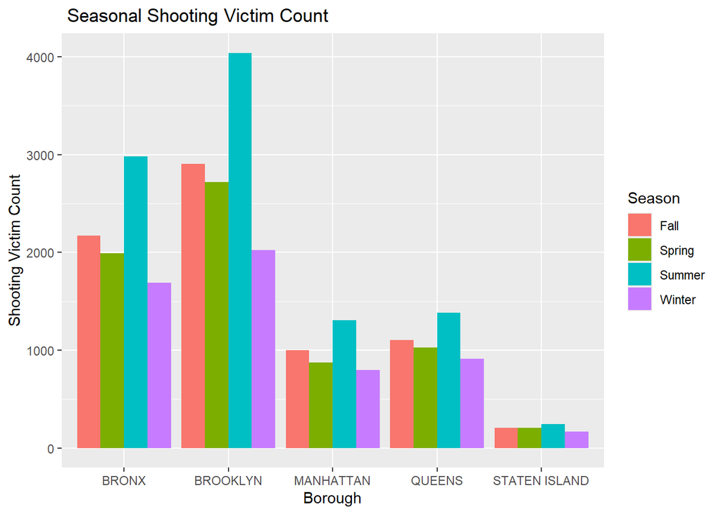

```r
#making data visual that demonstrates shooting count per season and Borough
ggplot(data = shooting.final, aes(x = Borough, y = vic.count, fill = Season)) +
  geom_col(position = "dodge") +
  labs(x = "Borough", y = "Shooting Victim Count", title = " Seasonal Shooting Victim Count")
```

## Data Visualization Plot #1

My initial graph is a simple bar graph that shows a overall trend of the number of shooting victims per Borough and season. At a quick glance my first question seems to be answered. There is a definite variation between season with Summer being the season with most Victims across all Boroughs.

```r
#take into account the year data increase
yearly.data = shooting.season %>%
  group_by(Borough, Season, year) %>%
  summarize(vic.count = n())

yearly.data
```

| Borough | Season | year | vic.count |
| --- | --- | --- | --- |
| BRONX | Fall | 2006 | 166 |
| BRONX | Fall | 2007 | 141 |
| BRONX | Fall | 2008 | 111 |
| BRONX | Fall | 2009 | 135 |
| BRONX | Fall | 2010 | 127 |
| BRONX | Fall | 2011 | 169 |
| BRONX | Fall | 2012 | 110 |
| BRONX | Fall | 2013 | 114 |
| BRONX | Fall | 2014 | 88 |
| BRONX | Fall | 2015 | 92 |

[output cut: 370 more lines]

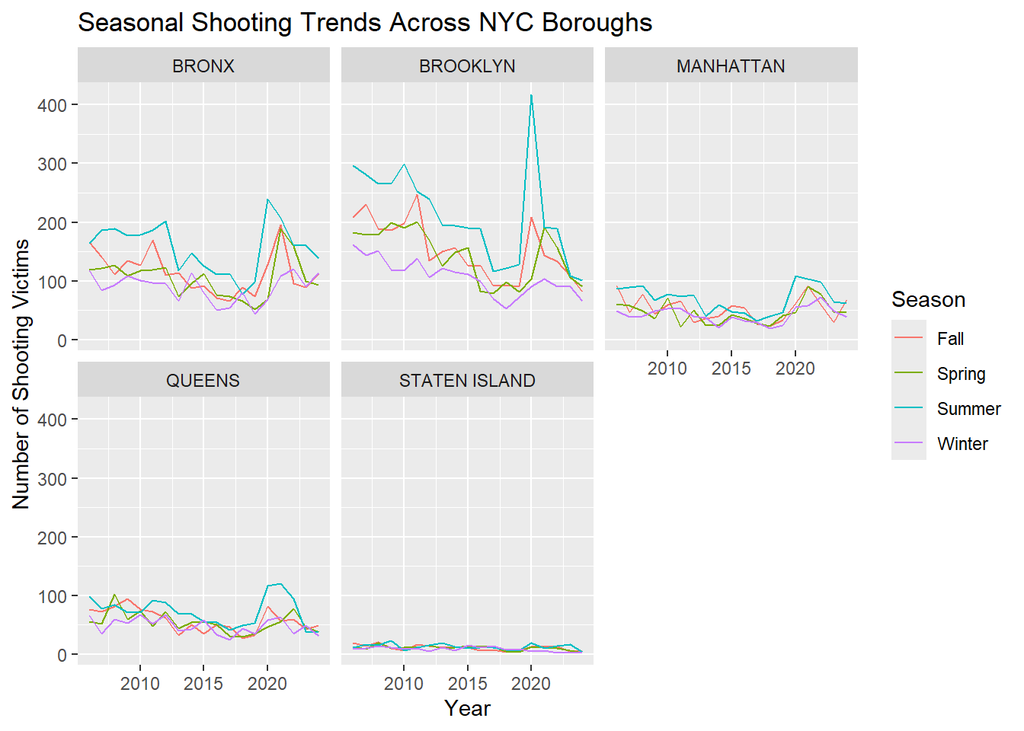

```r
#plot the trend of shootings for each borough throughout the seasons and years
ggplot(yearly.data, aes(x = year, y = vic.count, color = Season)) +
  geom_line() +
  facet_wrap(~ Borough) +
  labs(title = "Seasonal Shooting Trends Across NYC Boroughs", x = "Year", y = "Number of Shooting Victims", color = "Season")
```

## Data Visualization Plot #2

This graph visualizes the victim count data throughout the years. Viewing it we do see that there is still a trend of summer having the most shooting victims. However, now we are able to see a couple of different years were this is not the case throughout all the Boroughs. We also see that 2020 seem to have a dramatic jump in shooting victims throughout the Boroughs, but especially in Brooklyn.

```r
#make a linear regression model to determine statistical significance of each predictor interacting with one anoterh
mod.shooting = lm(vic.count ~ year * Season * Borough, data = yearly.data)

summary(mod.shooting)
```

```
##
## Call:
## lm(formula = vic.count ~ year * Season * Borough, data = yearly.data)
##
## Residuals:
##     Min      1Q  Median      3Q     Max
## -80.716 -10.853  -0.947   9.761 244.237
##
## Coefficients:
##                                          Estimate Std. Error t value Pr(>|t|)
## (Intercept)                             4.311e+03  2.351e+03   1.833  0.06763
## year                                   -2.082e+00  1.167e+00  -1.785  0.07521
## SeasonSpring                           -2.795e+03  3.325e+03  -0.841  0.40116
## SeasonSummer                           -7.954e+02  3.325e+03  -0.239  0.81109
## SeasonWinter                           -3.119e+03  3.325e+03  -0.938  0.34894
## BoroughBROOKLYN                         8.650e+03  3.325e+03   2.601  0.00969
## BoroughMANHATTAN                       -3.105e+03  3.325e+03  -0.934  0.35100
## BoroughQUEENS                          -4.842e+02  3.325e+03  -0.146  0.88431
## BoroughSTATEN ISLAND                   -3.292e+03  3.325e+03  -0.990  0.32285
## year:SeasonSpring                       1.382e+00  1.650e+00   0.838  0.40276
## year:SeasonSummer                       4.158e-01  1.650e+00   0.252  0.80122
## year:SeasonWinter                       1.535e+00  1.650e+00   0.930  0.35291
## year:BoroughBROOKLYN                   -4.274e+00  1.650e+00  -2.590  0.01002
## year:BoroughMANHATTAN                   1.511e+00  1.650e+00   0.915  0.36065
## year:BoroughQUEENS                      2.123e-01  1.650e+00   0.129  0.89772
## year:BoroughSTATEN ISLAND               1.582e+00  1.650e+00   0.959  0.33827
## SeasonSpring:BoroughBROOKLYN            1.942e+02  4.703e+03   0.041  0.96708
## SeasonSummer:BoroughBROOKLYN            4.136e+03  4.703e+03   0.879  0.37976
## SeasonWinter:BoroughBROOKLYN           -9.258e+02  4.703e+03  -0.197  0.84404
## SeasonSpring:BoroughMANHATTAN           9.855e+02  4.703e+03   0.210  0.83412
## SeasonSummer:BoroughMANHATTAN           5.076e+02  4.703e+03   0.108  0.91411
## SeasonWinter:BoroughMANHATTAN           1.630e+03  4.703e+03   0.347  0.72901
## SeasonSpring:BoroughQUEENS              1.667e+03  4.703e+03   0.355  0.72315
## SeasonSummer:BoroughQUEENS             -8.230e+02  4.703e+03  -0.175  0.86117
## SeasonWinter:BoroughQUEENS              1.239e+03  4.703e+03   0.263  0.79235
## SeasonSpring:BoroughSTATEN ISLAND       2.526e+03  4.703e+03   0.537  0.59146
## SeasonSummer:BoroughSTATEN ISLAND       3.378e+02  4.703e+03   0.072  0.94278
## SeasonWinter:BoroughSTATEN ISLAND       2.947e+03  4.703e+03   0.627  0.53130
## year:SeasonSpring:BoroughBROOKLYN      -9.649e-02  2.334e+00  -0.041  0.96704
## year:SeasonSummer:BoroughBROOKLYN      -2.044e+00  2.334e+00  -0.876  0.38176
```

[output cut: 42 more lines]

```
## year:SeasonSpring:BoroughMANHATTAN
## year:SeasonSummer:BoroughMANHATTAN
## year:SeasonWinter:BoroughMANHATTAN
## year:SeasonSpring:BoroughQUEENS
## year:SeasonSummer:BoroughQUEENS
## year:SeasonWinter:BoroughQUEENS
## year:SeasonSpring:BoroughSTATEN ISLAND
## year:SeasonSummer:BoroughSTATEN ISLAND
## year:SeasonWinter:BoroughSTATEN ISLAND
## ---
## Signif. codes:  0 '***' 0.001 '**' 0.01 '*' 0.05 '.' 0.1 ' ' 1
##
## Residual standard error: 27.86 on 340 degrees of freedom
## Multiple R-squared:  0.8243, Adjusted R-squared:  0.8041
## F-statistic: 40.89 on 39 and 340 DF,  p-value: < 2.2e-16
```

```r
#use data to predict trend
yearly.data$predicted = predict(mod.shooting)

head(yearly.data)
```

| Borough | Season | year | vic.count | predicted |
| --- | --- | --- | --- | --- |
| BRONX | Fall | 2006 | 166 | 133.1632 |
| BRONX | Fall | 2007 | 141 | 131.0807 |
| BRONX | Fall | 2008 | 111 | 128.9982 |
| BRONX | Fall | 2009 | 135 | 126.9158 |
| BRONX | Fall | 2010 | 127 | 124.8333 |
| BRONX | Fall | 2011 | 169 | 122.7509 |

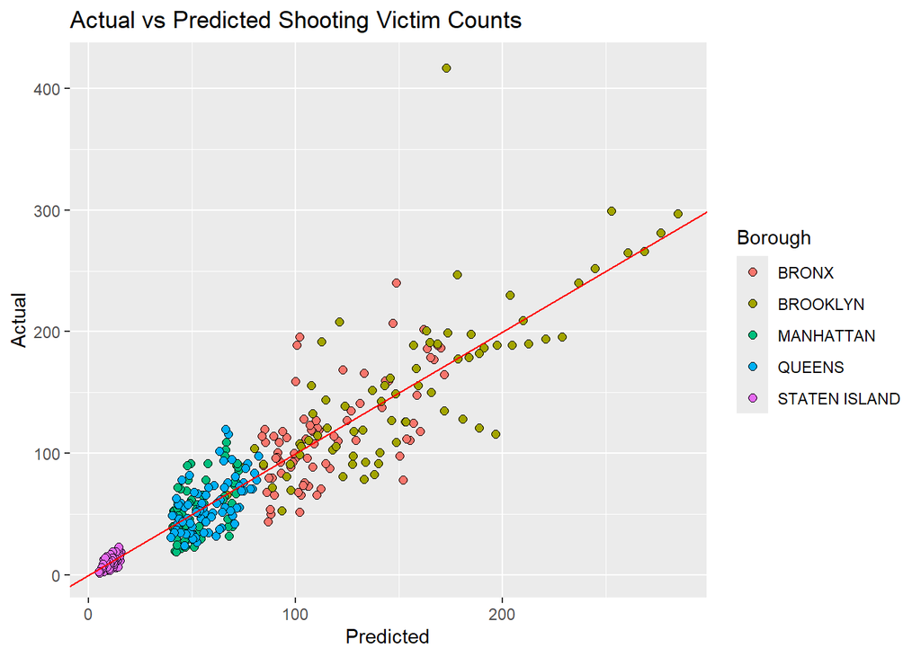

```r
yearly.data %>%
  ggplot(aes(x = predicted, y = vic.count, fill = Borough)) +
  geom_point(shape = 21, size = 2) +
  geom_abline(slope = 1, intercept = 0, color = "red") +
  labs(title = "Actual vs Predicted Shooting Victim Counts", x = "Predicted", y = "Actual")
```

## Data Visualization – Model

This graph compares the actual shooting victim counts with the values predicted by the linear regression model. Points closer to the red line indicate a better fit, while points farther away represent larger prediction errors. From this graph, we can see that Staten Island has less variation in its shooting victim counts, while Brooklyn and the Bronx show greater variation.

## Bias Identification

One personal bias in this data project is that I chose this specific topic to avoid other topics involving race. I made this decision because I feel that those topics are more nuanced than what can be fully accounted for through data collection alone.

Another potential source of bias is that the data does not account for borough population sizes or tourism. These factors could influence shooting victim counts and make direct comparisons between boroughs misleading.

Other potential biases include inaccuracies in data collection and differences in how shootings are reported or recorded. Because of these limitations, the results should not be interpreted as evidence of a causal relationship, but rather as associations between the variables.